# Predicting Total Cost of Ischemic Heart Disease and With Characteristic and Medical Touchpoint Data

Tanner Kulbashian

December 10, 2017

**Summary:** In this study, the relationship between total cost of ischemic heart disease $Y_i$ and possible covariates $X_{ij}$ have been analyzed and modeled from the Linear Regression Kutner, et. al. textbook (Appendix C.09). *

## I. Introduction:

For this analysis, there is a sample of 788 patients with total cost $Y_i$ and a host of assorted health features $X_{ij}$. The data for the claim costs ranged from $0 to $52,664.90. Predictors $X_{ij}$ considered in this analysis include age, gender, claim duration, and counts of interventions, drug, emergency room visits, complications, and comorbidities. The relationship is modeled using a first-order linear regression model ands some variable transformations are tested. Several model validation techniques are used to assess the soundness of the model fit and diagnostics, and there is a discussion of key assumptions.

##### **Tested Variables:**

$Y_i$ = Total Cost  
$X_{1j}$ = Age  
$X_{2j}$ = Gender  
$X_{3j}$ = Interventions (count)  
$X_{4j}$ = Drugs (count)  
$X_{5j}$ = Emergency Room Visits (count)  
$X_{6j}$ = Complications (count)  
$X_{7j}$ = Comorbdities (count)  
$X_{8j}$ = Duration

##### **Initial Model:**

The **initial model** is given by:

$$Y_i = \beta_0 + \beta_1X_{i1} + \beta_2X_{i2} + \beta_3X_{i3} + \beta_4X_{i4} + \beta_5X_{i5} + \beta_6X_{i6} + \beta_7X_{i7} + \beta_8X_{i8} + \varepsilon_i$$

where $\varepsilon_i \sim iidN(0,\sigma^2)$, $i = 1, 2, . . . , 788$, and $\beta_0, \beta_1, . . . , \beta_8,$ and $\sigma^2$ are the unknown model parameters.

## II. Preliminary Analysis

#### *Figure A: Original Dataset Preview*

```
##   id total_cost age gender interventions drugs emergency_visits
## 1  1      179.1  63      0             2     1                4
## 2  2      319.0  59      0             2     0                6
## 3  3     9310.7  62      0            17     0                2
## 4  4      280.9  60      1             9     0                7
## 5  5    18727.1  55      0             5     2                7
## 6  6      453.4  66      0             1     0                3
##   complications comorbidities duration
## 1             0             3      300
## 2             0             0      120
## 3             0             5      353
## 4             0             2      332
## 5             0             0       18
## 6             0             4      296
```

#### *Figure B: Univariate Plots*

Most of the univariate plots of the potential covariates appear ready for modeling, but drugs, complications, and comorbidities have skewed distributions that could affect model fit. The response variable
$$Y_i$$
also appears skewed and should be tested with log-transformation at a further point.

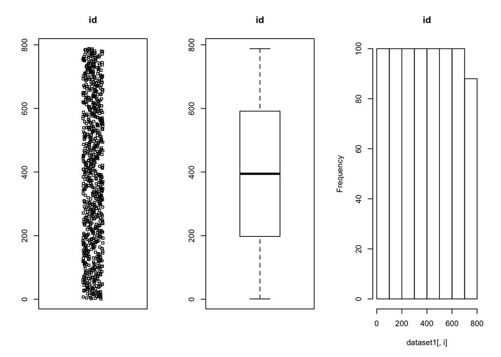

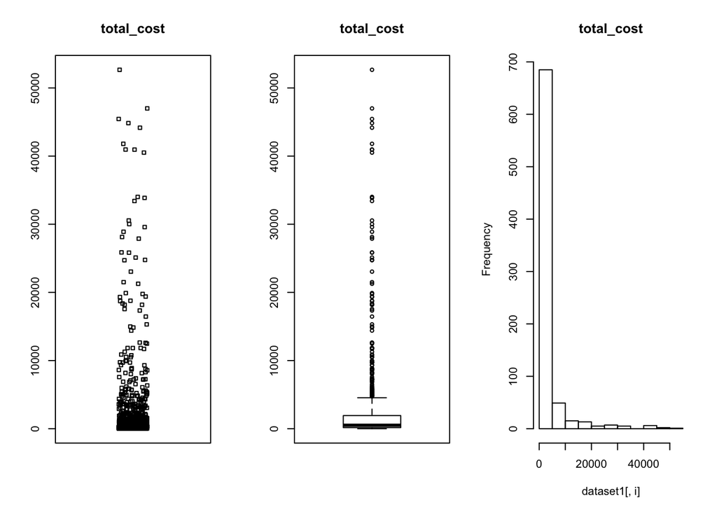

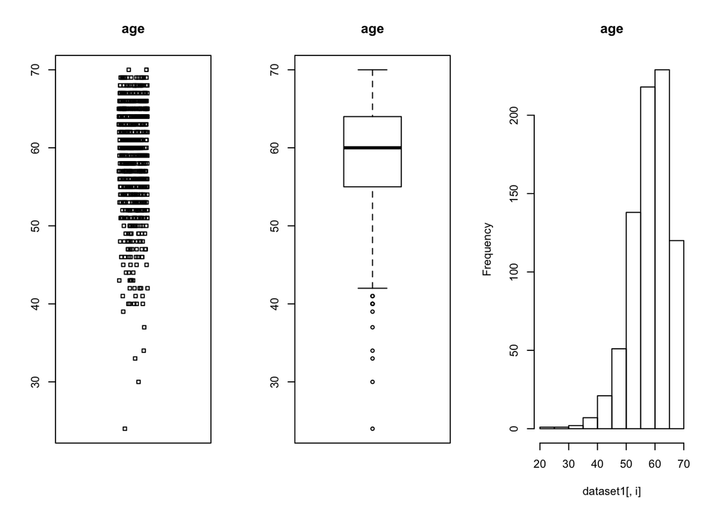

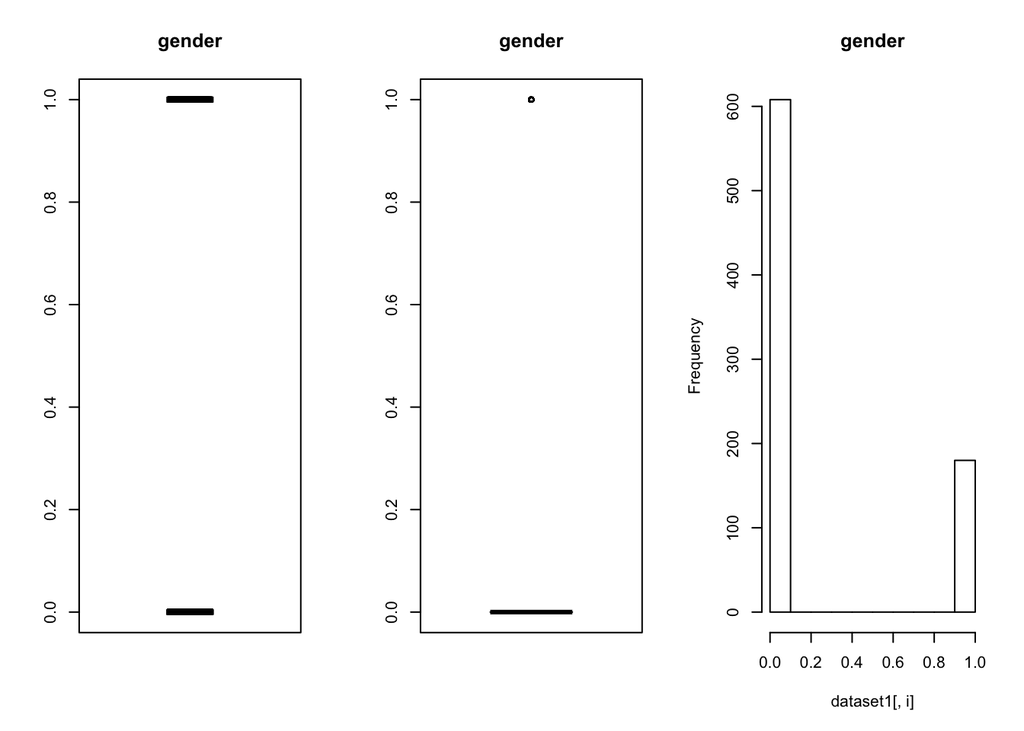

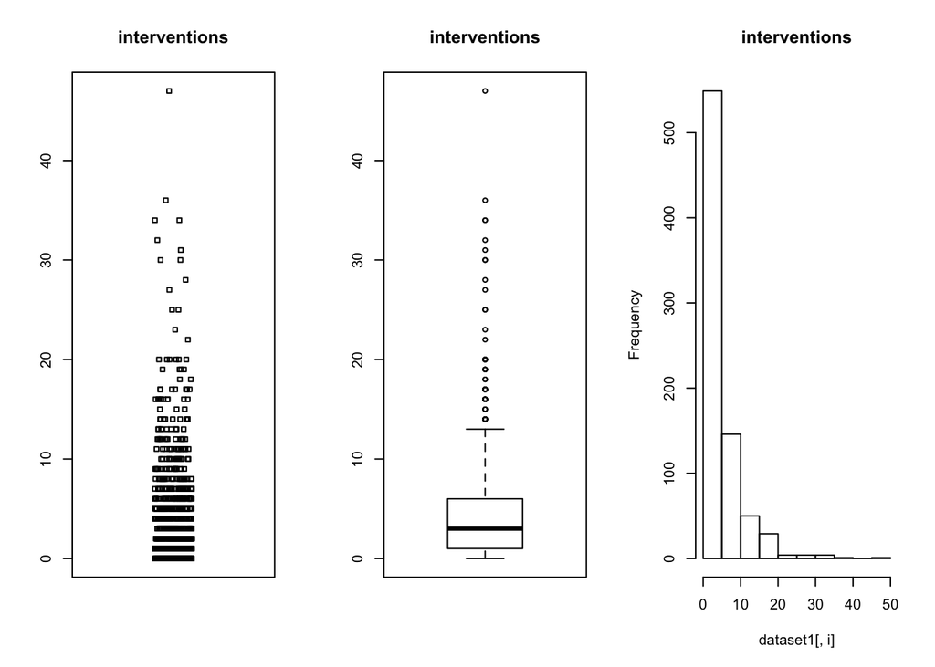

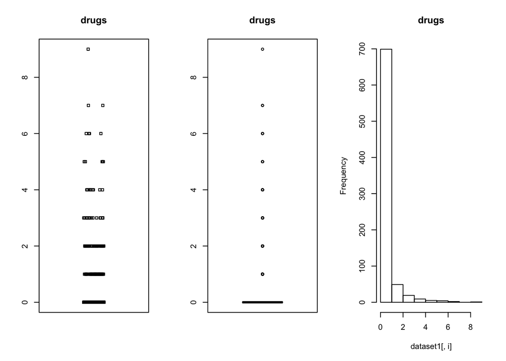

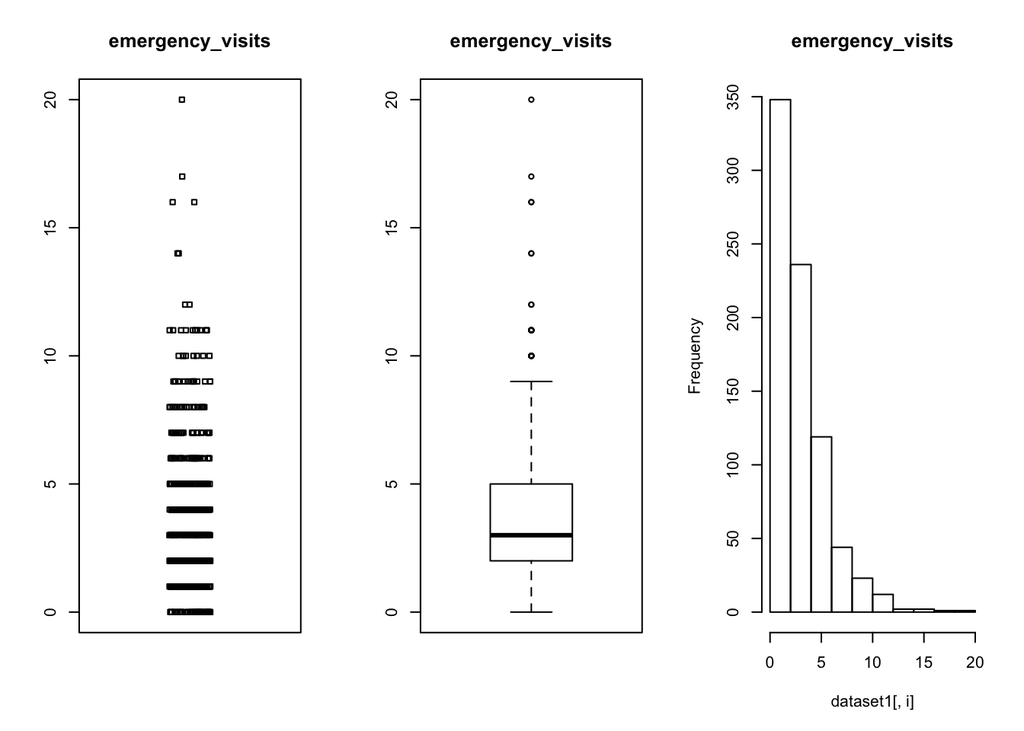

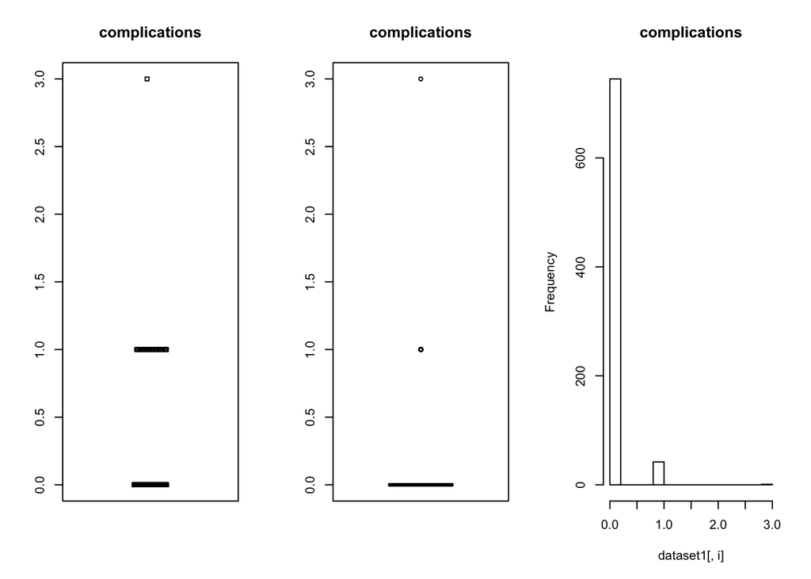

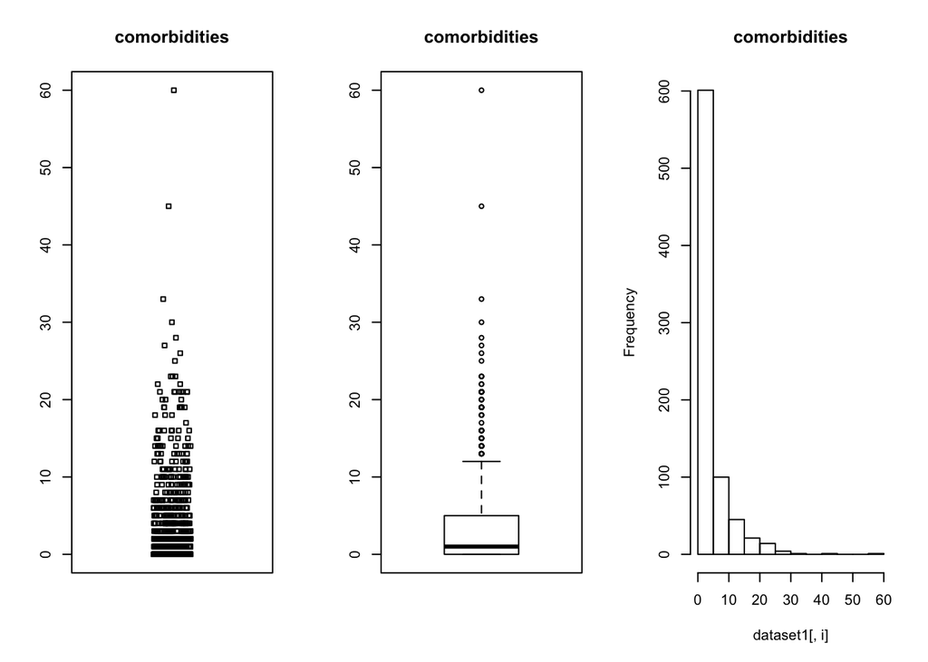

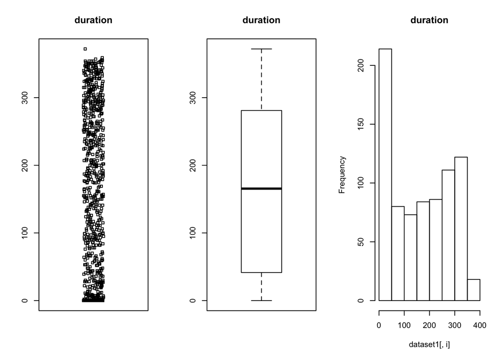

##### **Initial Relationship and Correlation Detection:**

#### *Figure C: Bivariate Associations Plot: Total Cost and Possible Covariates*

The correlations don’t appear too severely in plots nor in the pearson correlation table. The covariate interventions is strongly correlated with the $Y_i$ total cost (Pearson’s *r* = 0.727) and emergency visits is fairly correlated too (*r* = 0.377). Addressing correlation between potential covariates, emergency visits is correlated with interventions (*r* = 0.367) and drugs (*r*= 0.528), as well as comorbidities and duration (*r* = 0.495). Drugs and intereventions, as well as duration and interventions, both have Pearson’s *r* of just greater than 0.22. Correlations should be monitored during feature selection, and final variance inflation factors (VIF) should be checked subsequently.

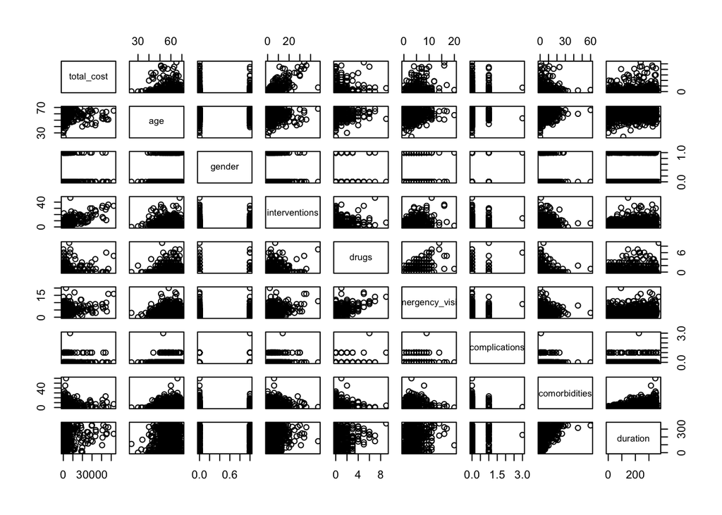

#### *Figure D: Pearson Correlation Table*

```
##                            id   total_cost         age       gender
## id                1.000000000 -0.005790549  0.01897077  0.009674045
## total_cost       -0.005790549  1.000000000 -0.05874852 -0.018525445
## age               0.018970775 -0.058748523  1.00000000 -0.018043018
## gender            0.009674045 -0.018525445 -0.01804302  1.000000000
## interventions     0.012925911  0.726755443 -0.03167889  0.032853234
## drugs            -0.013789430  0.181944239  0.02673140  0.030119696
## emergency_visits  0.017291060  0.376657987  0.06215487  0.110643031
## complications     0.013738179  0.182428864 -0.04271363  0.033175348
## comorbidities     0.021301196  0.146005805  0.09367482 -0.041154772
## duration          0.031014280  0.175676403  0.13551739  0.023552266
##                  interventions       drugs emergency_visits complications
## id                  0.01292591 -0.01378943       0.01729106    0.01373818
## total_cost          0.72675544  0.18194424       0.37665799    0.18242886
## age                -0.03167889  0.02673140       0.06215487   -0.04271363
## gender              0.03285323  0.03011970       0.11064303    0.03317535
## interventions       1.00000000  0.22953160       0.36676833    0.19610253
## drugs               0.22953160  1.00000000       0.52771831    0.14876413
## emergency_visits    0.36676833  0.52771831       1.00000000    0.16093851
## complications       0.19610253  0.14876413       0.16093851    1.00000000
## comorbidities       0.14899747 -0.05093854       0.03078128    0.03228381
## duration            0.22637435  0.06477961       0.14470949    0.07589605
##                  comorbidities   duration
## id                  0.02130120 0.03101428
## total_cost          0.14600580 0.17567640
## age                 0.09367482 0.13551739
## gender             -0.04115477 0.02355227
## interventions       0.14899747 0.22637435
## drugs              -0.05093854 0.06477961
## emergency_visits    0.03078128 0.14470949
## complications       0.03228381 0.07589605
## comorbidities       1.00000000 0.49518636
## duration            0.49518636 1.00000000
```

## III. Statistical Analysis

$$\hat{Y} = 637.55 -46.72X_{1} + -932.26X_{2} + 812.08X_{3} - 376.53X_{4} + 427.66X_{5} + \varepsilon_i$$

on 782 degrees of freedom.

#### *Figure E: Final Model Summary and ANOVA Table*

```
##
## Call:
## lm(formula = total_cost ~ age + gender + interventions + drugs +
##     emergency_visits, data = dataset1)
##
## Residuals:
##    Min     1Q Median     3Q    Max
## -30308  -1702    -56   1235  36196
##
## Coefficients:
##                  Estimate Std. Error t value Pr(>|t|)
## (Intercept)        637.55    1421.35   0.449   0.6539
## age                -46.72      23.86  -1.959   0.0505 .
## gender            -932.26     384.75  -2.423   0.0156 *
## interventions      812.08      30.92  26.263  < 2e-16 ***
## drugs             -376.53     177.88  -2.117   0.0346 *
## emergency_visits   427.66      75.68   5.651 2.23e-08 ***
## ---
## Signif. codes:  0 '***' 0.001 '**' 0.01 '*' 0.05 '.' 0.1 ' ' 1
##
## Residual standard error: 4502 on 782 degrees of freedom
## Multiple R-squared:   0.55,  Adjusted R-squared:  0.5471
## F-statistic: 191.2 on 5 and 782 DF,  p-value: < 2.2e-16
```

```
## Analysis of Variance Table
##
## Response: total_cost
##                   Df     Sum Sq    Mean Sq  F value    Pr(>F)
## age                1 1.2158e+08 1.2158e+08   5.9977   0.01454 *
## gender             1 1.3517e+07 1.3517e+07   0.6668   0.41442
## interventions      1 1.8580e+10 1.8580e+10 916.6191 < 2.2e-16 ***
## drugs              1 1.1206e+07 1.1206e+07   0.5528   0.45739
## emergency_visits   1 6.4733e+08 6.4733e+08  31.9343 2.234e-08 ***
## Residuals        782 1.5852e+10 2.0271e+07
## ---
## Signif. codes:  0 '***' 0.001 '**' 0.01 '*' 0.05 '.' 0.1 ' ' 1
```

## IV. Summary of Findings / General Discussion

Normality of errors question the validity of this model as soundly explaining total cost of ischemic heart disease in claimants. Further variables could be collected that could assuage the curvilinear relationship and heteroskedascity in the final model residuals. Further, they could improve the Q-Q plot on the right-hand side. However, the $R_2$ of 0.5471 indicates that a high proportion of variation in total cost can be explained by the covariates thus far featured in the model.

## V. References

Kutner, M.H., Nachtsheim, C.J., Neter, J., Li, W. (2005), *Applied Linear Statistical Models*, 5th Edition, McGraw-Hill Irwin, New York, NY.

## VI. Appendix

### Feature Screening and Regression Modeling Assumptions

#### *Figure F: Automatic Feature Selection with Leaps*

An exhaustive search with the “regsubsets” function is initially performed for all covariate combinations to pick the best model for each possible number of parameters (1 through 8).

Ultimately, three model diagnostics suggest either 5 or 6 covariates is ideal for optimal model fit. First, $R_2$ peaks at parameter 7, but both 5 and 6 appear close in value. Next, BIC suggests 2 parameters but 5 is relatively close too. Finally, Mallow’s $C_p$ suggests 6, because it’s closest to *p* (# of beta coefficents).

Combining analyses from automatic feature selection with “Leaps” and three model diagnostics suggests removing the bottom 3 covariates: duration, complications, and comorbidities. Age could either be included or excluded, and a formal full vs. reduced hypothesis testing should reveal if it improves model fit or should be rejected in favor of parmisony.

```
## Subset selection object
## Call: regsubsets.formula(total_cost ~ duration + age + gender + interventions +
##     drugs + emergency_visits + complications + comorbidities,
##     data = dataset1)
## 8 Variables  (and intercept)
##                  Forced in Forced out
## duration             FALSE      FALSE
## age                  FALSE      FALSE
## gender               FALSE      FALSE
## interventions        FALSE      FALSE
## drugs                FALSE      FALSE
## emergency_visits     FALSE      FALSE
## complications        FALSE      FALSE
## comorbidities        FALSE      FALSE
## 1 subsets of each size up to 8
## Selection Algorithm: exhaustive
##          duration age gender interventions drugs emergency_visits
## 1  ( 1 ) " "      " " " "    "*"           " "   " "
## 2  ( 1 ) " "      " " " "    "*"           " "   "*"
## 3  ( 1 ) " "      " " "*"    "*"           " "   "*"
## 4  ( 1 ) " "      " " "*"    "*"           "*"   "*"
## 5  ( 1 ) " "      "*" "*"    "*"           "*"   "*"
## 6  ( 1 ) " "      "*" "*"    "*"           "*"   "*"
## 7  ( 1 ) " "      "*" "*"    "*"           "*"   "*"
## 8  ( 1 ) "*"      "*" "*"    "*"           "*"   "*"
##          complications comorbidities
## 1  ( 1 ) " "           " "
## 2  ( 1 ) " "           " "
## 3  ( 1 ) " "           " "
## 4  ( 1 ) " "           " "
## 5  ( 1 ) " "           " "
## 6  ( 1 ) " "           "*"
## 7  ( 1 ) "*"           "*"
## 8  ( 1 ) "*"           "*"
```

#### *Figure G: Adjusted $R^2$ for Incremental Parameters*

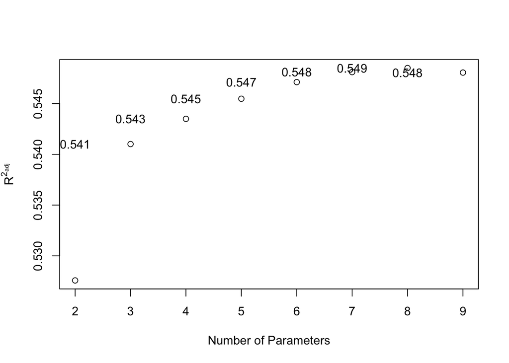

```
## [1] 0.5275732 0.5410150 0.5434978 0.5454808 0.5471209 0.5481081 0.5485082
## [8] 0.5480601
```

#### *Figure H: BIC for Incremental Parameters*

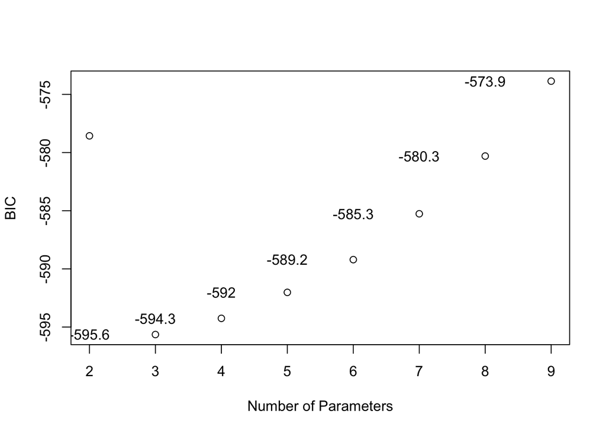

```
## [1] -578.5624 -595.6419 -594.2510 -592.0177 -589.2039 -585.2623 -580.3003
## [8] -573.8600
```

#### *Figure I: Mallow’s $C_p$ for Incremental Parameters*

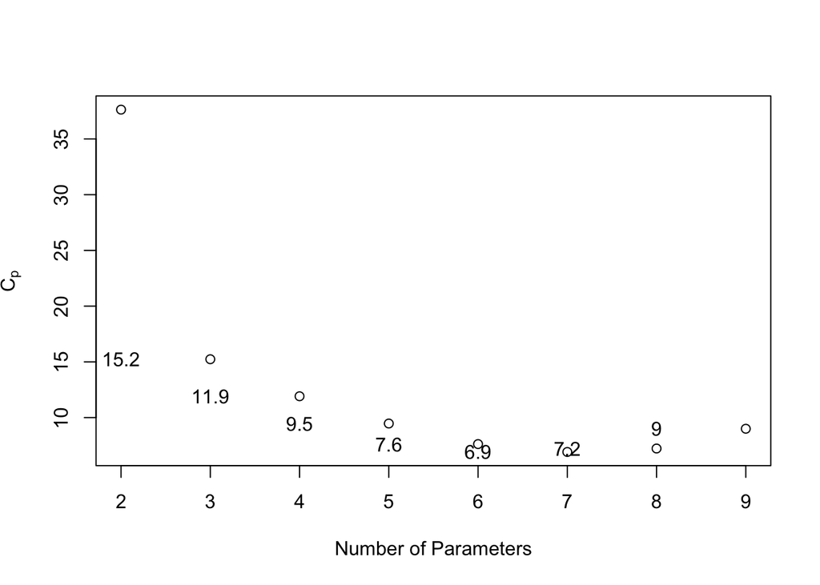

```
## [1] 37.630151 15.237039 11.914392  9.468706  7.624977  6.916938  7.226623
## [8]  9.000000
```

#### *Figure J: Reduced Model Summary (ex age) and ANOVA Table*

```
##
## Call:
## lm(formula = total_cost ~ gender + interventions + drugs + emergency_visits,
##     data = dataset1)
##
## Residuals:
##    Min     1Q Median     3Q    Max
## -30816  -1647    -85   1253  36039
##
## Coefficients:
##                  Estimate Std. Error t value Pr(>|t|)
## (Intercept)      -2090.53     283.29  -7.379 4.06e-13 ***
## gender            -912.80     385.32  -2.369   0.0181 *
## interventions      815.63      30.92  26.376  < 2e-16 ***
## drugs             -374.66     178.20  -2.102   0.0358 *
## emergency_visits   416.72      75.61   5.512 4.83e-08 ***
## ---
## Signif. codes:  0 '***' 0.001 '**' 0.01 '*' 0.05 '.' 0.1 ' ' 1
##
## Residual standard error: 4510 on 783 degrees of freedom
## Multiple R-squared:  0.5478, Adjusted R-squared:  0.5455
## F-statistic: 237.1 on 4 and 783 DF,  p-value: < 2.2e-16
```

```
## Analysis of Variance Table
##
## Response: total_cost
##                   Df     Sum Sq    Mean Sq  F value    Pr(>F)
## gender             1 1.2089e+07 1.2089e+07   0.5942    0.4410
## interventions      1 1.8657e+10 1.8657e+10 917.0545 < 2.2e-16 ***
## drugs              1 9.6311e+06 9.6311e+06   0.4734    0.4916
## emergency_visits   1 6.1801e+08 6.1801e+08  30.3777 4.829e-08 ***
## Residuals        783 1.5929e+10 2.0344e+07
## ---
## Signif. codes:  0 '***' 0.001 '**' 0.01 '*' 0.05 '.' 0.1 ' ' 1
```

#### *Figure K: Partial Residual Plots*

Emergency visits and interventions exhibit heteroskedascity in the error terms, and will be tested further with log-transformations for any curvilinear relationships.

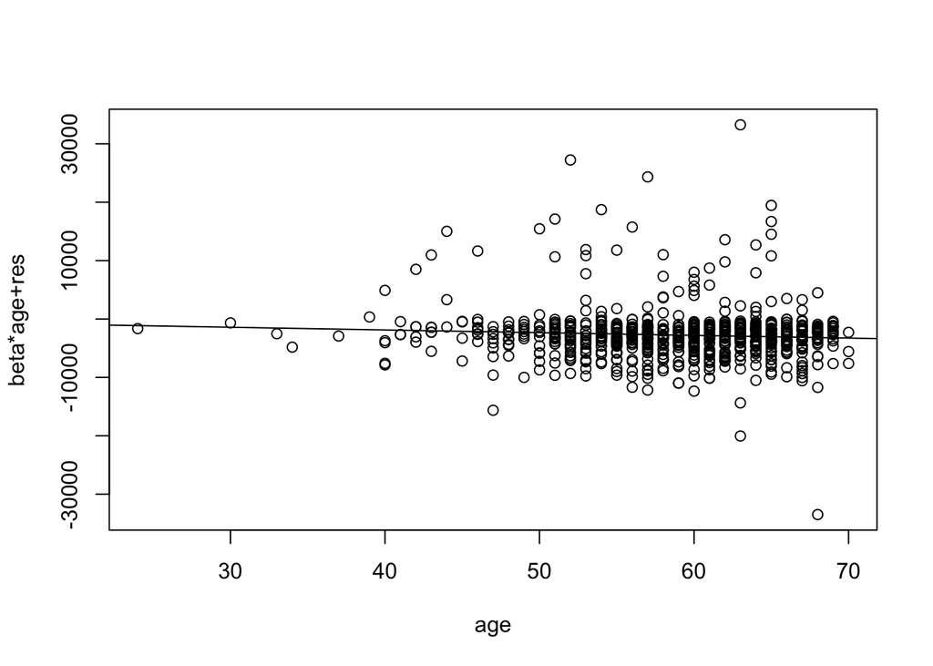

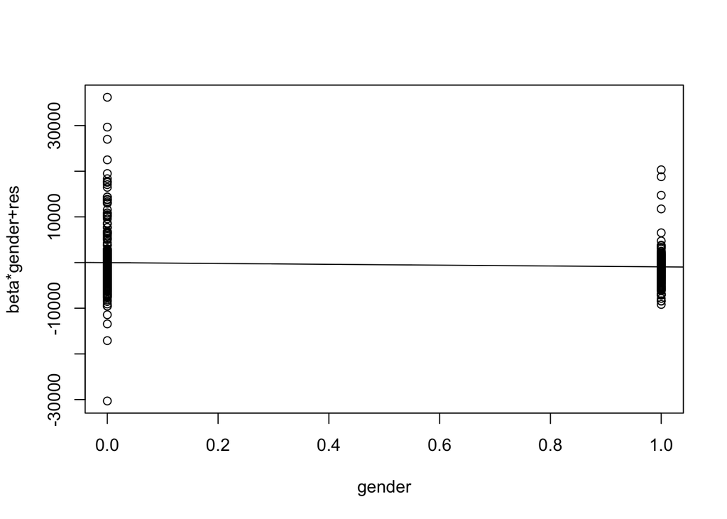

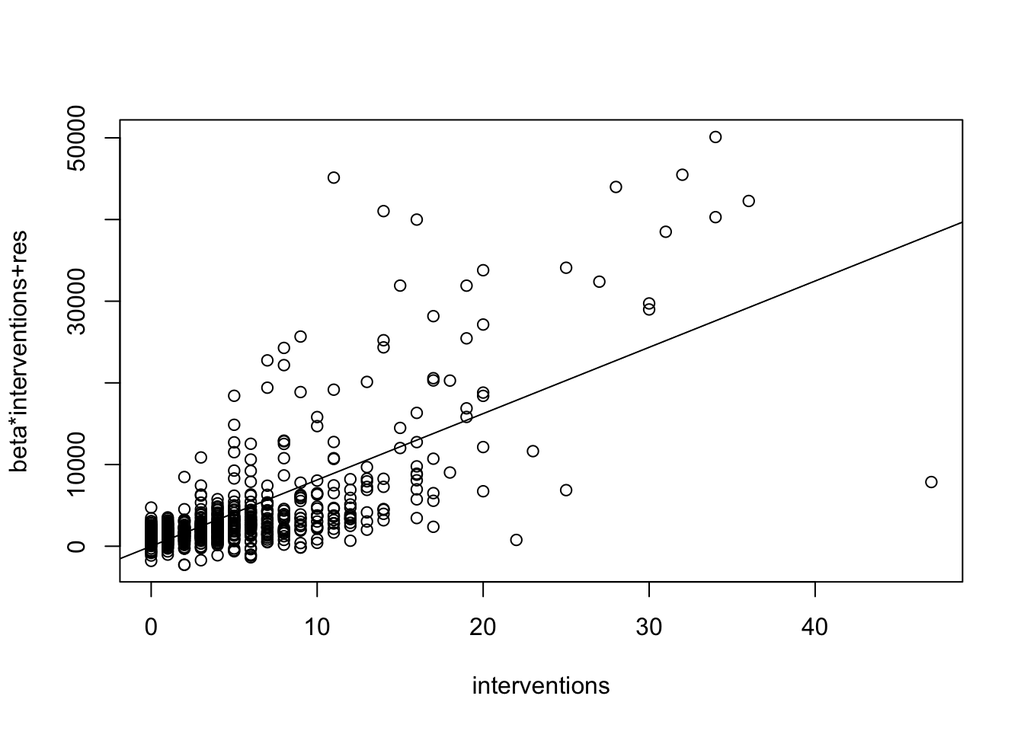

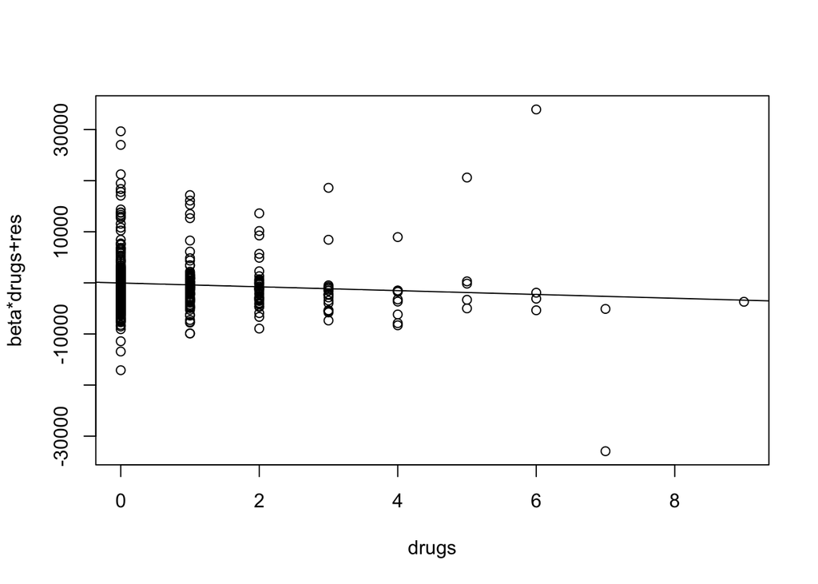

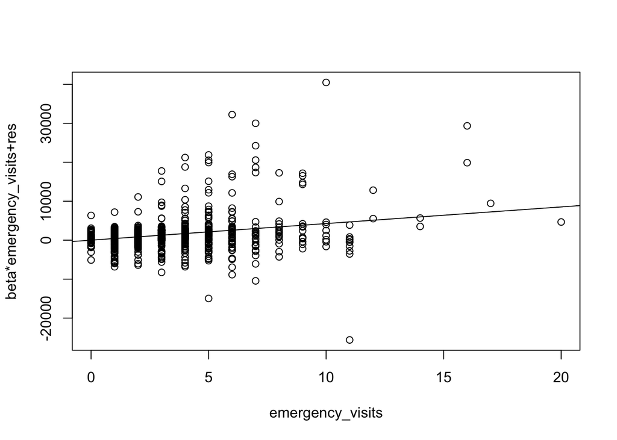

#### *Figure L: VIF Multicollinearity Test*

No paramaters exhibit a variance inflation factor greater than 1.54, which indicates that multicollinearity should not impact the regression model fit.

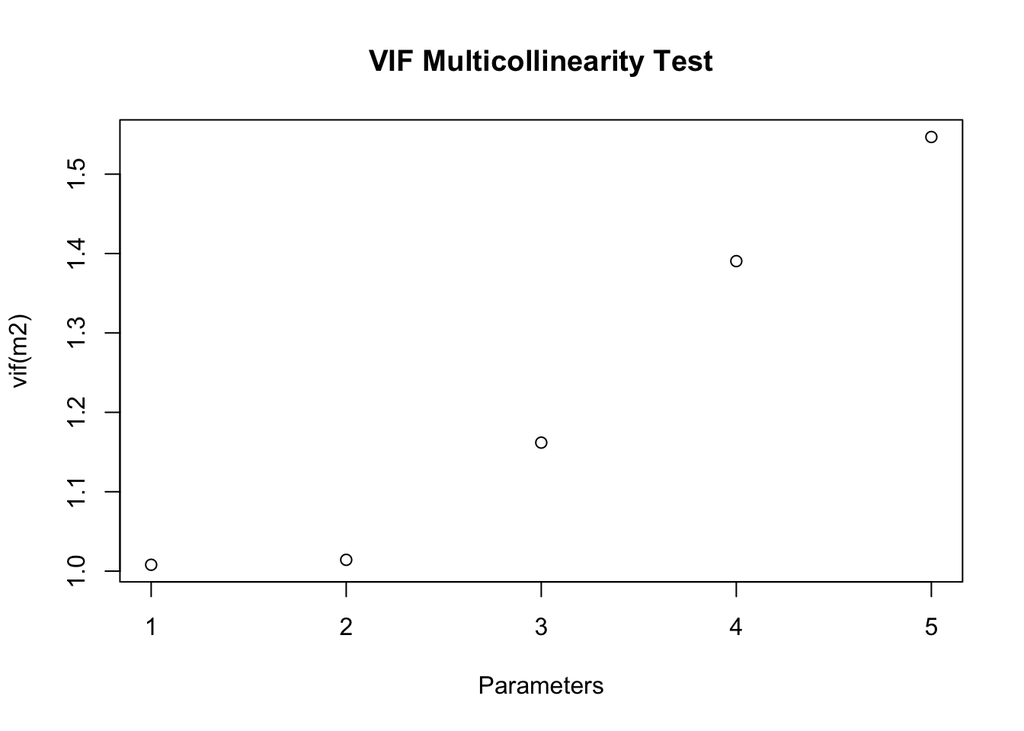

#### *Figure M: Residuals Plot with Model Fit Line*

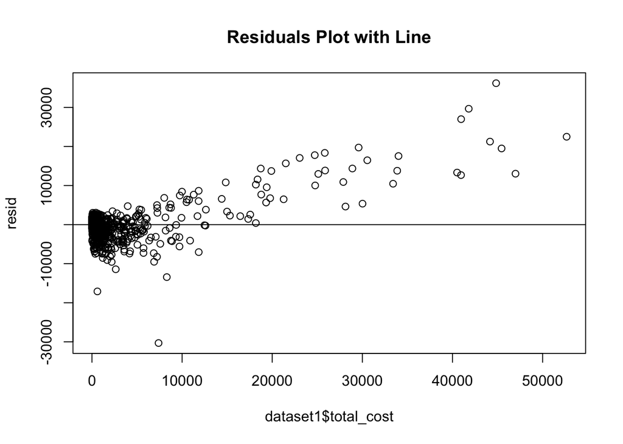

#### *Figure N: Breusch-Pagan Test*

```
## Non-constant Variance Score Test
## Variance formula: ~ fitted.values
## Chisquare = 1706.092    Df = 1     p = 0
```

#### *Figure O: Studentized Residuals Plot*

Some unevenly distributed points appear in the studentized residuals plot toward the left, but should not impact the model fit too much.

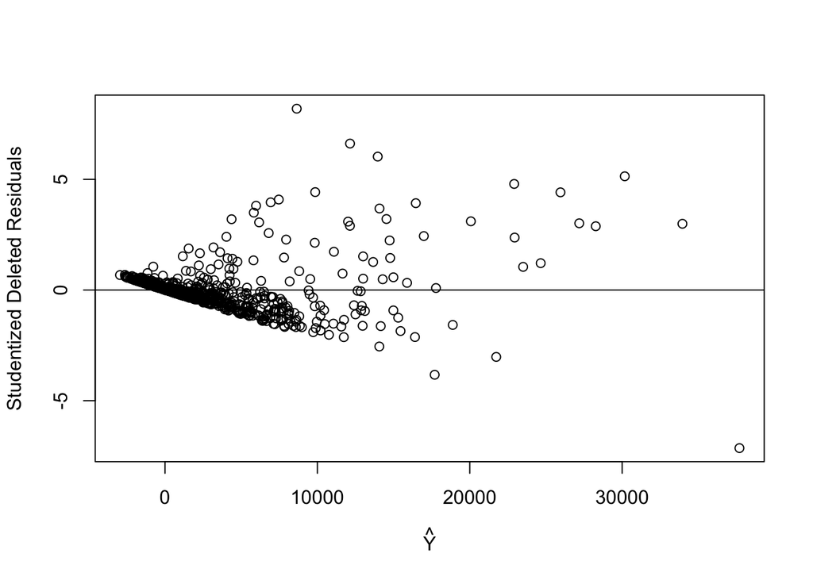

#### *Figure P: Q-Q Plot*

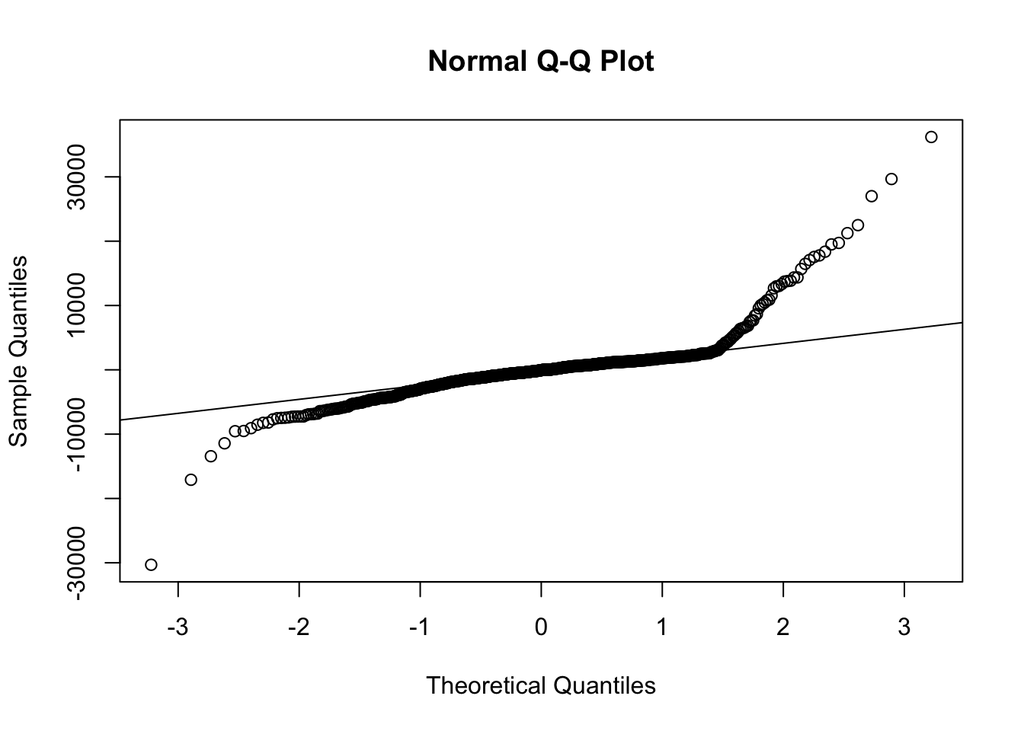

## Checking Independence

#### *Figure Q: Sequence Plot of Residuals*

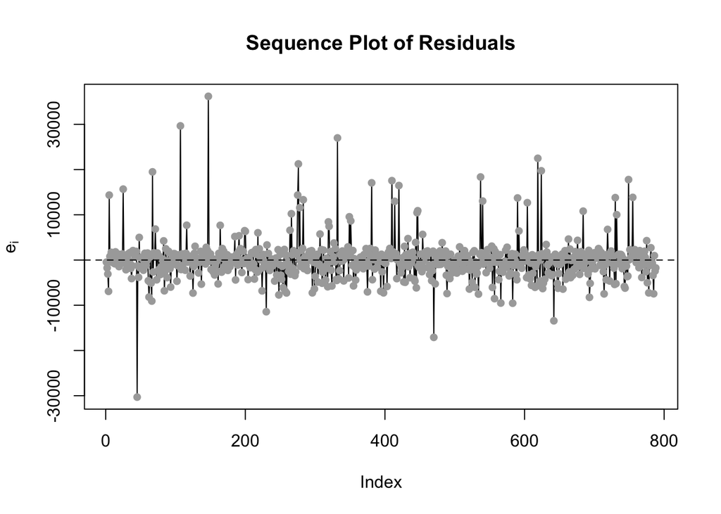

```
##
## Call:
## lm(formula = residuals(m2)[-1] ~ -1 + residuals(m2)[-47])
##
## Residuals:
##    Min     1Q Median     3Q    Max
## -32015   -185     -8    124  26074
##
## Coefficients:
##                    Estimate Std. Error t value Pr(>|t|)
## residuals(m2)[-47]   0.9025     0.0154   58.61   <2e-16 ***
## ---
## Signif. codes:  0 '***' 0.001 '**' 0.01 '*' 0.05 '.' 0.1 ' ' 1
##
## Residual standard error: 1938 on 786 degrees of freedom
## Multiple R-squared:  0.8138, Adjusted R-squared:  0.8136
## F-statistic:  3435 on 1 and 786 DF,  p-value: < 2.2e-16
```

#### *Figure R: Cook’s Distance Plot*

Both points 45 and 147 should be monitored as outliers because of their affect when removed from the model, as well as their high influence positions in
$$X_i$$
.

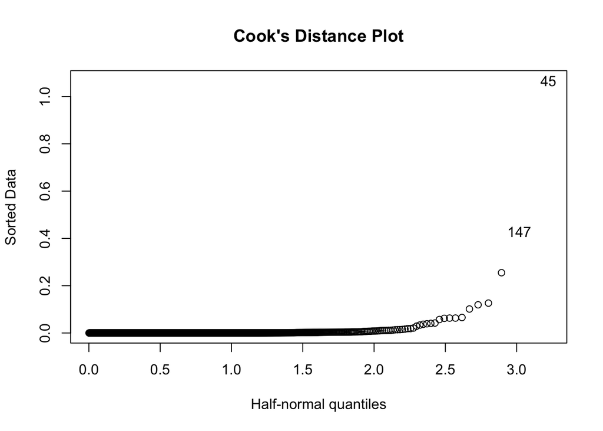

#### *Figure S: Testing Removal of Outliers*

While removing outliers 45 and 147 improved the model fit in terms of $R^2$, the model fit was fine beforehand. Leaving outliers in the final model does compromise model fit nor does it change the final model selection enough to warrant a removal.

```
##
## Call:
## lm(formula = total_cost ~ age + gender + interventions + drugs +
##     emergency_visits, data = dataset1, subset = c(-45, -147))
##
## Residuals:
##      Min       1Q   Median       3Q      Max
## -17976.1  -1658.1     29.9   1387.2  29321.8
##
## Coefficients:
##                  Estimate Std. Error t value Pr(>|t|)
## (Intercept)        139.23    1320.60   0.105   0.9161
## age                -40.24      22.14  -1.817   0.0696 .
## gender            -918.58     356.58  -2.576   0.0102 *
## interventions      865.76      29.58  29.265  < 2e-16 ***
## drugs             -374.91     170.31  -2.201   0.0280 *
## emergency_visits   385.64      70.41   5.477 5.83e-08 ***
## ---
## Signif. codes:  0 '***' 0.001 '**' 0.01 '*' 0.05 '.' 0.1 ' ' 1
##
## Residual standard error: 4170 on 780 degrees of freedom
## Multiple R-squared:  0.5943, Adjusted R-squared:  0.5917
## F-statistic: 228.5 on 5 and 780 DF,  p-value: < 2.2e-16
```

#### *Figure T: Model Summaries–Testing Models with Log-transformations*

```
##
## Call:
## lm(formula = total_cost_log ~ age + gender + interventions +
##     drugs + emergency_visits, data = dataset2.a)
##
## Residuals:
##     Min      1Q  Median      3Q     Max
## -7.0979 -0.7699  0.1101  0.8554  3.3293
##
## Coefficients:
##                    Estimate Std. Error t value Pr(>|t|)
## (Intercept)       5.0406279  0.4307454  11.702  < 2e-16 ***
## age               0.0002187  0.0072300   0.030  0.97587
## gender           -0.1693489  0.1166007  -1.452  0.14680
## interventions     0.2294946  0.0093707  24.491  < 2e-16 ***
## drugs            -0.0830942  0.0539070  -1.541  0.12362
## emergency_visits  0.0677771  0.0229344   2.955  0.00322 **
## ---
## Signif. codes:  0 '***' 0.001 '**' 0.01 '*' 0.05 '.' 0.1 ' ' 1
##
## Residual standard error: 1.364 on 782 degrees of freedom
## Multiple R-squared:  0.491,  Adjusted R-squared:  0.4877
## F-statistic: 150.9 on 5 and 782 DF,  p-value: < 2.2e-16
```

```
##
## Call:
## lm(formula = total_cost ~ age + gender + interventions_log +
##     drugs + emergency_visits, data = dataset2.b)
##
## Residuals:
##    Min     1Q Median     3Q    Max
## -10183  -2663   -495   1690  35381
##
## Coefficients:
##                   Estimate Std. Error t value Pr(>|t|)
## (Intercept)        1145.45    1685.89   0.679   0.4971
## age                 -68.02      28.21  -2.411   0.0161 *
## gender            -1123.45     455.45  -2.467   0.0139 *
## interventions_log  3423.13     208.93  16.384  < 2e-16 ***
## drugs              -383.30     210.75  -1.819   0.0693 .
## emergency_visits    668.99      88.15   7.589 9.18e-14 ***
## ---
## Signif. codes:  0 '***' 0.001 '**' 0.01 '*' 0.05 '.' 0.1 ' ' 1
##
## Residual standard error: 5329 on 782 degrees of freedom
## Multiple R-squared:  0.3695, Adjusted R-squared:  0.3655
## F-statistic: 91.66 on 5 and 782 DF,  p-value: < 2.2e-16
```

```
##
## Call:
## lm(formula = total_cost ~ age + gender + interventions + drugs +
##     emergency_visits_log, data = dataset2.c)
##
## Residuals:
##    Min     1Q Median     3Q    Max
## -30615  -1755    -89   1213  36314
##
## Coefficients:
##                      Estimate Std. Error t value Pr(>|t|)
## (Intercept)            679.14    1430.63   0.475   0.6351
## age                    -46.27      24.03  -1.925   0.0545 .
## gender                -869.56     386.73  -2.249   0.0248 *
## interventions          827.42      30.74  26.920  < 2e-16 ***
## drugs                 -194.36     169.72  -1.145   0.2525
## emergency_visits_log  1227.29     263.83   4.652 3.86e-06 ***
## ---
## Signif. codes:  0 '***' 0.001 '**' 0.01 '*' 0.05 '.' 0.1 ' ' 1
##
## Residual standard error: 4531 on 782 degrees of freedom
## Multiple R-squared:  0.5442, Adjusted R-squared:  0.5413
## F-statistic: 186.8 on 5 and 782 DF,  p-value: < 2.2e-16
```

```
##
## Call:
## lm(formula = total_cost ~ age + gender + interventions^2 + drugs +
##     emergency_visits, data = dataset1)
##
## Residuals:
##    Min     1Q Median     3Q    Max
## -30308  -1702    -56   1235  36196
##
## Coefficients:
##                  Estimate Std. Error t value Pr(>|t|)
## (Intercept)        637.55    1421.35   0.449   0.6539
## age                -46.72      23.86  -1.959   0.0505 .
## gender            -932.26     384.75  -2.423   0.0156 *
## interventions      812.08      30.92  26.263  < 2e-16 ***
## drugs             -376.53     177.88  -2.117   0.0346 *
## emergency_visits   427.66      75.68   5.651 2.23e-08 ***
## ---
## Signif. codes:  0 '***' 0.001 '**' 0.01 '*' 0.05 '.' 0.1 ' ' 1
##
## Residual standard error: 4502 on 782 degrees of freedom
## Multiple R-squared:   0.55,  Adjusted R-squared:  0.5471
## F-statistic: 191.2 on 5 and 782 DF,  p-value: < 2.2e-16
```

```
##
## Call:
## lm(formula = total_cost ~ age + gender + interventions + drugs +
##     emergency_visits^2, data = dataset1)
##
## Residuals:
##    Min     1Q Median     3Q    Max
## -30308  -1702    -56   1235  36196
##
## Coefficients:
##                  Estimate Std. Error t value Pr(>|t|)
## (Intercept)        637.55    1421.35   0.449   0.6539
## age                -46.72      23.86  -1.959   0.0505 .
## gender            -932.26     384.75  -2.423   0.0156 *
## interventions      812.08      30.92  26.263  < 2e-16 ***
## drugs             -376.53     177.88  -2.117   0.0346 *
## emergency_visits   427.66      75.68   5.651 2.23e-08 ***
## ---
## Signif. codes:  0 '***' 0.001 '**' 0.01 '*' 0.05 '.' 0.1 ' ' 1
##
## Residual standard error: 4502 on 782 degrees of freedom
## Multiple R-squared:   0.55,  Adjusted R-squared:  0.5471
## F-statistic: 191.2 on 5 and 782 DF,  p-value: < 2.2e-16
```